# Makay and Isalo: GBIF documentation comparison

Audited and corrected version (2026-11-13)

## Setup

This document compares GBIF occurrence documentation for the Makay and Isalo protected areas (Madagascar). It is the corrected output of a reproducibility audit (2026-11-13) of an earlier version of this report; every methodological change is documented inline and in `audit_report.md`.

The pipeline reads a GBIF occurrence download stored as a partitioned parquet dataset, and the World Database on Protected Areas (WDPA) polygons for the two sites.

```r
library(arrow) # to read parquet
library(tidyverse) # for data manipulation
library(scales) # scale conversion
library(sf) # vector spatial data
library(tmap) # map visualization

# define paths
wdpa_zip <- "data/raw/wdpa/WDPA_Jul2026_MDG-shapefile.zip"
wdpa_gdb <- "data/raw/wdpa/WDPA_WDOECM_Jul2026_Public_MDG.gdb"
parquet_dir <- "data/parquet/gbif_madagascar"
dataset_names_path <- "outputs/gbif_dataset_names.csv"
# keep consistent colors across document
area_colors <- c(Makay = "#3b7a57", Isalo = "#c85c3e")
```

## Provenance

All occurrence data come from a single GBIF occurrence download:

- **Download key**: `0000459-260720095953322`; **DOI**: 10.15468/dl.ufwdju
- **Created** 2026-07-20 19:51 UTC, completed 22:53 UTC; format `SIMPLE_CSV` (50 columns)
- **Predicate**: `occurrenceStatus = PRESENT` AND `country = MG` (Madagascar)
- **3,635,415 records** from 2,006 datasets, licensed **CC BY-NC 4.0**
- Converted to a lon/lat-partitioned parquet dataset by `R/convert_gbif_madagascar_to_parquet.R`. The audit found and fixed two conversion defects in the superseded converter (see *Audit notes* at the end of this document): silently dropped records caused by malformed quoting in the source CSV (262 records with stray unescaped `"` characters caused readr’s chunked reader to lose ~300,486 records), and 70,239,134 all-NA “phantom” rows created by `NA`-propagating logical subsetting. The corrected dataset contains exactly 3,635,415 records (verified against the GBIF API) and all 50 source columns, including `kingdom`, `phylum`, `taxonRank`, `taxonKey` and `speciesKey`.

Protected-area boundaries come from the **WDPA/WDOECM July 2026 public release** (`WDPA_Jul2026_MDG-shapefile.zip`, MD5 `d96a919e7ce1ed8389c9da863f692d8d`, internal file dates 2026-07-16). The cached archive is read directly with GDAL’s OpenFileGDB driver. (The `wdpar::wdpa_fetch()` download-page scraping used previously no longer works; `wdpa_read()` performed no geometry processing beyond unzipping, so reading the geodatabase directly reproduces the same polygons.)

```r
# extract the geodatabase from the cached WDPA zip if needed
if (!dir.exists(wdpa_gdb)) {
  utils::unzip(wdpa_zip, exdir = dirname(wdpa_zip))
}

protected_areas <- st_read(wdpa_gdb, layer = "WDPA_WDOECM_poly_Jul2026_MDG", quiet = TRUE) |>
  mutate(area = coalesce(NAME_ENG, NAME)) |>
  filter(str_detect(area, regex("makay|isalo", ignore_case = TRUE))) |>
  st_make_valid() |>
  rename(geometry = SHAPE) |>
  select(area, SITE_ID, DESIG_ENG, IUCN_CAT, STATUS, STATUS_YR, REP_AREA, GIS_AREA, geometry) |>
  # Area on the ellipsoidal equal-area projection EPSG:6933; this reproduces
  # WDPA's own GIS_AREA column exactly. The earlier report used EPSG:29702
  # (Laborde, conformal: 4,052 / 866 km²) and an earlier script used geodesic
  # area on the WGS84 ellipsoid (4,067 / 869 km²); see audit notes.
  mutate(AREA_KM2 = as.numeric(st_area(st_transform(geometry, 6933))) / 1000000) |>
  st_transform(4326)
```

## Protected areas

Both polygons are WDPA site polygons, not geomorphological outlines of the massifs: Isalo (WDPA site 2312) is a national park (IUCN category II, designated 1962); Makay (WDPA site 555790177) is a proposed protected area (“Aire Protégée”, status Proposed, 2015). The two polygons do not overlap and there is exactly one polygon per site.

```r
tmap_mode("view")

tm_shape(protected_areas) +
  tm_polygons(
    col = "area",
    palette = area_colors,
    alpha = 0.7,
    border.col = "#1f1f1f",
    lwd = 1.5,
    id = "area"
  ) +
  tm_text("area")
```

[interactive chart not shown]

## Madagascar GBIF and filtering

The filtering workflow starts from all 3,635,415 PRESENT records of the GBIF Madagascar download, narrows the data to the parquet partitions touched by the two protected areas (a prefilter to avoid loading the full extract), keeps records inside the rectangular bounding box of each area, and finally keeps only points within the exact WDPA polygons (`st_within`, so the polygons themselves — not their bounding boxes — define the study areas).

```r
# columns used in this document
required_columns <- c(
  "gbifID", "decimalLongitude", "decimalLatitude", "species", "scientificName",
  "year", "datasetKey", "basisOfRecord", "kingdom", "phylum", "class",
  "taxonRank", "speciesKey", "genus", "family",
  "coordinateUncertaintyInMeters", "occurrenceStatus"
)

# per-area bounding boxes (computed per feature, then floored to 1-degree bins)
bbox_matrix <- t(vapply(
  st_geometry(protected_areas),
  \(geometry) unname(st_bbox(geometry)),
  numeric(4)
))
colnames(bbox_matrix) <- c("xmin", "ymin", "xmax", "ymax")
area_bboxes <- as_tibble(bbox_matrix) |>
  mutate(area = protected_areas$area)

candidate_occurrences <- open_dataset(parquet_dir) |>
  select(any_of(c(required_columns, "lon_bin", "lat_bin"))) |>
  filter(
    lon_bin %in% 44:45,
    lat_bin %in% -23:-21,
    !is.na(decimalLongitude),
    !is.na(decimalLatitude),
    is.na(occurrenceStatus) | occurrenceStatus == "PRESENT"
  ) |>
  collect()

bbox_counts <- candidate_occurrences |>
  mutate(
    in_isalo = decimalLongitude >= area_bboxes$xmin[area_bboxes$area == "Isalo"] &
      decimalLongitude <= area_bboxes$xmax[area_bboxes$area == "Isalo"] &
      decimalLatitude >= area_bboxes$ymin[area_bboxes$area == "Isalo"] &
      decimalLatitude <= area_bboxes$ymax[area_bboxes$area == "Isalo"],
    in_makay = decimalLongitude >= area_bboxes$xmin[area_bboxes$area == "Makay"] &
      decimalLongitude <= area_bboxes$xmax[area_bboxes$area == "Makay"] &
      decimalLatitude >= area_bboxes$ymin[area_bboxes$area == "Makay"] &
      decimalLatitude <= area_bboxes$ymax[area_bboxes$area == "Makay"]
  ) |>
  summarise(Isalo = sum(in_isalo), Makay = sum(in_makay)) |>
  pivot_longer(everything(), names_to = "area", values_to = "record_count") |>
  mutate(step = "Inside bounding box")

area_occurrences <- candidate_occurrences |>
  st_as_sf(coords = c("decimalLongitude", "decimalLatitude"), crs = 4326, remove = FALSE) |>
  st_join(protected_areas |> select(area), join = st_within, left = FALSE) |>
  st_drop_geometry() |>
  mutate(record_year = suppressWarnings(as.integer(year)))

filtering_steps <- tibble(
  step = c(
    "GBIF Madagascar download (PRESENT records, verified against the GBIF API)",
    "Candidate records read from parquet bins (with coordinates)",
    "Inside bounding box",
    "Clipped to exact WDPA polygon (st_within)"
  ),
  record_count = c(
    3635415L,
    nrow(candidate_occurrences),
    sum(bbox_counts$record_count),
    nrow(area_occurrences)
  )
) |>
  mutate(share_of_madagascar = record_count / first(record_count))
```

```r
filtering_steps |>
  mutate(
    across(record_count, comma),
    share_of_madagascar = percent(share_of_madagascar, accuracy = 0.01)
  ) |>
  knitr::kable(caption = "Filtering pipeline from the GBIF Madagascar download to the polygon-clipped occurrences")
```

Filtering pipeline from the GBIF Madagascar download to the polygon-clipped occurrences

| step | record_count | share_of_madagascar |
| --- | --- | --- |
| GBIF Madagascar download (PRESENT records, verified against the GBIF API) | 3,635,415 | 100.00% |
| Candidate records read from parquet bins (with coordinates) | 235,989 | 6.49% |
| Inside bounding box | 76,666 | 2.11% |
| Clipped to exact WDPA polygon (st_within) | 60,456 | 1.66% |

The bbox stage removes most of the Madagascar archive before loading to memory, and the polygon stage then removes additional records that fall inside the rectangular extent but outside the protected-area boundary.

## Species definition (audit correction)

The earlier report counted “species” as `species_label = coalesce(species, scientificName)`. This construction counts **identifications of any rank** as species: when GBIF’s `species` field is empty (genus-, family- or order-level identifications, and unmatched names), the fallback `scientificName` contributes labels such as *Diptera*, *Chironomidae* or *Grewia* (with or without authorship) that are not species. In the earlier data the top “species” of Isalo by record count were *Diptera* (2,071), *Coleoptera* (1,941) and *Chironomidae* (1,859) — all higher-rank labels.

This document counts **accepted species** with the GBIF backbone identifier `speciesKey`, which is populated only for identifications at or below species rank and resolves synonyms to the accepted species. Two properties were verified in the data: (i) no record with a species-rank identification lacks a `speciesKey` (none are lost by this definition), and (ii) `speciesKey` and `species` agree except for six name strings shared by two homotypic backbone keys, so keys are used throughout. Records identified only above species rank (66% of Isalo occurrences, largely bulk arthropod samples identified to family/order; 33% of Makay occurrences, largely genus-level plant determinations) are retained in occurrence counts but contribute to no species count; they are reported separately as higher-rank identifications.

```r
higher_rank_labels <- area_occurrences |>
  filter(is.na(speciesKey), !is.na(scientificName)) |>
  count(area, scientificName, sort = TRUE) |>
  group_by(area) |>
  slice_head(n = 8) |>
  ungroup() |>
  rename(higher_rank_label = scientificName)

rank_breakdown <- area_occurrences |>
  filter(is.na(speciesKey)) |>
  count(area, taxonRank) |>
  pivot_wider(names_from = area, values_from = n, values_fill = 0) |>
  arrange(desc(Isalo))
```

```r
rank_breakdown |>
  mutate(across(Isalo:Makay, comma)) |>
  knitr::kable(caption = "Records without an accepted-species identifier, by identification rank")
```

Records without an accepted-species identifier, by identification rank

| taxonRank | Isalo | Makay |
| --- | --- | --- |
| FAMILY | 17,871 | 342 |
| ORDER | 9,341 | 3 |
| UNRANKED | 2,418 | 273 |
| GENUS | 2,376 | 1,802 |
| CLASS | 2,341 | 4 |
| KINGDOM | 555 | 24 |
| PHYLUM | 251 | 5 |
| INFRAKINGDOM | 76 | 0 |
| SUPERFAMILY | 72 | 0 |
| SUBFAMILY | 11 | 0 |
| INFRAORDER | 10 | 0 |
| SUBORDER | 7 | 0 |
| DOMAIN | 6 | 0 |
| SUBPHYLUM | 2 | 0 |
| INFRAPHYLUM | 1 | 0 |
| VARIETY | 1 | 0 |
| TRIBE | 0 | 3 |

```r
higher_rank_labels |>
  mutate(across(n, comma)) |>
  knitr::kable(caption = "Most frequent higher-rank identification labels (not counted as species)")
```

Most frequent higher-rank identification labels (not counted as species)

| area | higher_rank_label | n |
| --- | --- | --- |
| Isalo | Diptera | 2,130 |
| Isalo | Chironomidae Newman, 1834 | 2,120 |
| Isalo | Coleoptera | 1,998 |
| Isalo | Russulaceae Lotsy, 1907 | 1,858 |
| Isalo | Chrysomelidae Latreille, 1802 | 1,670 |
| Isalo | Cecidomyiidae Rye, 1874 | 1,523 |
| Isalo | Hymenoptera | 1,076 |
| Isalo | Arachnida | 1,043 |
| Makay | Formicidae Latreille, 1802 | 242 |
| Makay | Hypoponera Santschi, 1938 | 84 |
| Makay | Crematogaster Lund, 1831 | 62 |
| Makay | Xerophyta Juss. | 47 |
| Makay | Grewia L. | 45 |
| Makay | Secamone R.Br. | 42 |
| Makay | Eburopone Borowiec, 2016 | 33 |
| Makay | Parasyscia Emery, 1882 | 31 |

## Taxonomic scope comparison

The manuscript focuses on plants, so the comparison is reported for three nested scopes: all taxa, Plantae (as assigned by the GBIF backbone — including bryophytes and algae classified in Plantae), and vascular plants (phylum Tracheophyta).

```r
scope_comparison <- bind_rows(
  area_occurrences |> mutate(scope_name = "All taxa"),
  area_occurrences |> filter(kingdom == "Plantae") |>
    mutate(scope_name = "Plantae (GBIF backbone)"),
  area_occurrences |> filter(kingdom == "Plantae", phylum == "Tracheophyta") |>
    mutate(scope_name = "Vascular plants (Tracheophyta)")
) |>
  summarise(
    occurrences = n(),
    accepted_species = n_distinct(speciesKey[!is.na(speciesKey)]),
    higher_rank_only_records = sum(is.na(speciesKey)),
    .by = c(scope_name, area)
  ) |>
  left_join(protected_areas |> st_drop_geometry() |> select(area, AREA_KM2), by = "area") |>
  mutate(
    occurrence_density_per_100_km2 = occurrences / AREA_KM2 * 100,
    species_density_per_100_km2 = accepted_species / AREA_KM2 * 100
  )
```

```r
scope_comparison |>
  transmute(
    scope_name,
    area,
    area_km2 = round(AREA_KM2, 1),
    occurrences = comma(occurrences),
    accepted_species = comma(accepted_species),
    higher_rank_only_records = comma(higher_rank_only_records),
    occ_per_100_km2 = round(occurrence_density_per_100_km2, 1),
    species_per_100_km2 = round(species_density_per_100_km2, 1)
  ) |>
  knitr::kable(caption = "GBIF documentation by taxonomic scope (accepted species based on GBIF backbone speciesKey)")
```

GBIF documentation by taxonomic scope (accepted species based on GBIF backbone speciesKey)

| scope_name | area | area_km2 | occurrences | accepted_species | higher_rank_only_records | occ_per_100_km2 | species_per_100_km2 |
| --- | --- | --- | --- | --- | --- | --- | --- |
| All taxa | Makay | 4056.4 | 7,341 | 883 | 2,456 | 181.0 | 21.8 |
| All taxa | Isalo | 866.5 | 53,115 | 1,486 | 35,339 | 6129.6 | 171.5 |
| Plantae (GBIF backbone) | Makay | 4056.4 | 3,845 | 567 | 1,496 | 94.8 | 14.0 |
| Plantae (GBIF backbone) | Isalo | 866.5 | 4,573 | 649 | 532 | 527.7 | 74.9 |
| Vascular plants (Tracheophyta) | Makay | 4056.4 | 3,647 | 524 | 1,428 | 89.9 | 12.9 |
| Vascular plants (Tracheophyta) | Isalo | 866.5 | 4,454 | 622 | 449 | 514.0 | 71.8 |

For plants the raw contrast is much smaller than for all taxa: Isalo holds 622 vascular plant species against 524 for Makay, whereas Isalo holds almost twice as many accepted species across all taxa. The all-taxon asymmetry is largely produced by Isalo’s bulk arthropod and molecular sampling campaigns (see *Sampling profile*).

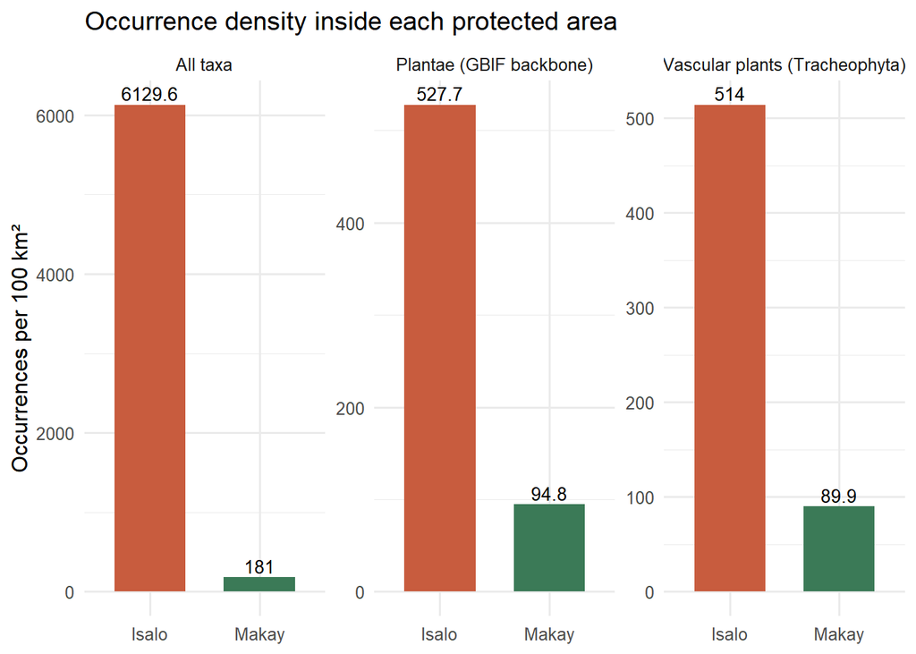

```r
ggplot(scope_comparison, aes(x = area, y = occurrence_density_per_100_km2, fill = area)) +
  geom_col(width = 0.65, show.legend = FALSE) +
  geom_text(aes(label = round(occurrence_density_per_100_km2, 1)), vjust = -0.3, size = 3.6) +
  facet_wrap(~ scope_name, scales = "free_y") +
  scale_fill_manual(values = area_colors) +
  labs(
    title = "Occurrence density inside each protected area",
    x = NULL,
    y = "Occurrences per 100 km²"
  ) +
  theme_minimal(base_size = 12)
```

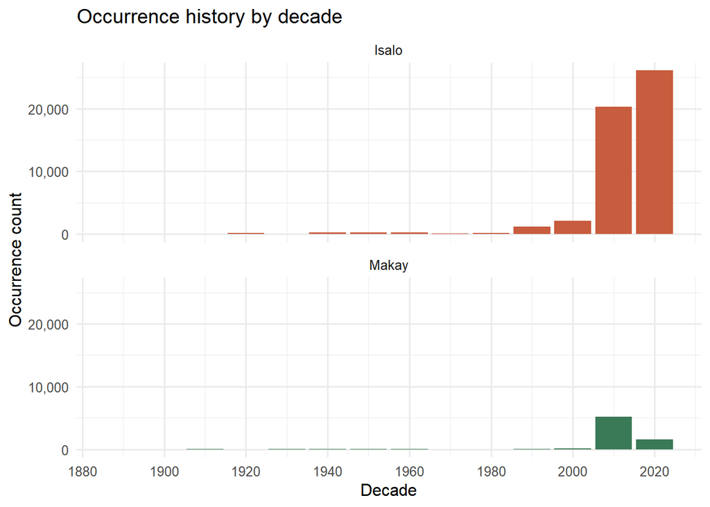

```r
decade_counts <- area_occurrences |>
  filter(!is.na(record_year), between(record_year, 1800, as.integer(format(Sys.Date(), "%Y")))) |>
  mutate(decade = (record_year %/% 10) * 10) |>
  summarise(occurrence_count = n(), .by = c(area, decade))

ggplot(decade_counts, aes(x = decade, y = occurrence_count, fill = area)) +
  geom_col(show.legend = FALSE) +
  facet_wrap(~ area, ncol = 1) +
  scale_fill_manual(values = area_colors) +
  scale_x_continuous(breaks = pretty_breaks(n = 8)) +
  scale_y_continuous(labels = comma) +
  labs(
    title = "Occurrence history by decade",
    x = "Decade",
    y = "Occurrence count"
  ) +
  theme_minimal(base_size = 12)
```

## Sampling profile

The two areas document different kinds of evidence. Isalo’s record set is dominated by molecular and bulk material samples, Makay’s by herbarium and insect specimens.

```r
basis_comparison <- area_occurrences |>
  count(area, basisOfRecord, name = "occurrence_count") |>
  mutate(share = occurrence_count / sum(occurrence_count), .by = area) |>
  arrange(area, desc(occurrence_count))

basis_comparison |>
  transmute(area, basisOfRecord, occurrences = comma(occurrence_count), share = percent(share, accuracy = 0.1)) |>
  knitr::kable(caption = "Basis of record composition")
```

Basis of record composition

| area | basisOfRecord | occurrences | share |
| --- | --- | --- | --- |
| Isalo | MATERIAL_SAMPLE | 35,102 | 66.1% |
| Isalo | HUMAN_OBSERVATION | 12,977 | 24.4% |
| Isalo | PRESERVED_SPECIMEN | 4,955 | 9.3% |
| Isalo | MATERIAL_CITATION | 51 | 0.1% |
| Isalo | OCCURRENCE | 26 | 0.0% |
| Isalo | MACHINE_OBSERVATION | 4 | 0.0% |
| Makay | PRESERVED_SPECIMEN | 5,995 | 81.7% |
| Makay | HUMAN_OBSERVATION | 654 | 8.9% |
| Makay | MATERIAL_SAMPLE | 645 | 8.8% |
| Makay | MATERIAL_CITATION | 43 | 0.6% |
| Makay | OCCURRENCE | 4 | 0.1% |

```r
# dataset contributions, with titles fetched from the GBIF dataset API
# (outputs/gbif_dataset_names.csv, fetched 2026-11-13)
dataset_names <- if (file.exists(dataset_names_path)) read_csv(dataset_names_path, show_col_types = FALSE) else NULL

dataset_stats <- area_occurrences |>
  count(area, datasetKey, name = "occurrences") |>
  mutate(share = occurrences / sum(occurrences), .by = area) |>
  arrange(area, desc(occurrences))

top_datasets <- dataset_stats |>
  group_by(area) |>
  slice_head(n = 5) |>
  ungroup() |>
  left_join(dataset_names, by = "datasetKey") |>
  mutate(dataset_title = coalesce(dataset_title, datasetKey))

top_datasets |>
  transmute(area, dataset = dataset_title, occurrences = comma(occurrences), share = percent(share, accuracy = 0.1)) |>
  knitr::kable(caption = "Five largest contributing datasets per area")
```

Five largest contributing datasets per area

| area | dataset | occurrences | share |
| --- | --- | --- | --- |
| Isalo | International Barcode of Life project (iBOL) | 15,641 | 29.4% |
| Isalo | CO1 Amplicon Sequence Variants of bulk arthropod samples (mild lysis) collected with Malaise traps from the Insect Biome Atlas project in Madagascar | 8,351 | 15.7% |
| Isalo | EOD – eBird Observation Dataset | 8,332 | 15.7% |
| Isalo | Global soil organisms | 8,096 | 15.2% |
| Isalo | iNaturalist Research-grade Observations | 3,892 | 7.3% |
| Makay | Tropicos Specimens Non-MO | 2,355 | 32.1% |
| Makay | AntWeb | 1,940 | 26.4% |
| Makay | Tropicos MO Specimen Data | 984 | 13.4% |
| Makay | International Barcode of Life project (iBOL) | 645 | 8.8% |
| Makay | iNaturalist Research-grade Observations | 478 | 6.5% |

Isalo’s material-sample mass comes from the International Barcode of Life project (29% of all Isalo records), CO1 amplicon sequence variants of bulk arthropod samples (16%) and the Global soil organisms dataset (15%); eBird checklists add another 16%. Makay’s records are dominated by Missouri Botanical Garden herbarium specimens (Tropicos: 45% of all Makay records) and AntWeb (26%). Within vascular plants, ~90% of Makay’s GBIF plant records are Tropicos herbarium specimens, while Isalo’s plant records are more mixed (iNaturalist 34%, Tropicos 29%, MNHN herbarium 13%).

Records are also strongly concentrated in space: **four distinct coordinate pairs hold 50% of all Isalo occurrences** (the most frequent pair holds 23%), consistent with bulk samples georeferenced to site or park centroids, whereas Makay’s records are far less repeated (top pair 3%; 43 distinct coordinates needed to reach 50%). Occurrence densities therefore partly reflect georeferencing practice rather than sampling intensity alone.

## Species overlap

```r
species_presence <- area_occurrences |>
  filter(!is.na(speciesKey)) |>
  distinct(area, speciesKey)

shared_species_count <- species_presence |> count(speciesKey) |> filter(n == 2) |> nrow()
unique_species <- species_presence |>
  add_count(speciesKey, name = "area_count") |>
  filter(area_count == 1) |>
  select(area, speciesKey)
species_union_count <- n_distinct(species_presence$speciesKey)
species_total_count <- nrow(species_presence)

overlap_metrics <- tibble(
  shared_species_count = shared_species_count,
  species_union_count = species_union_count,
  jaccard_similarity = shared_species_count / species_union_count,
  sorensen_similarity = 2 * shared_species_count / species_total_count
)

scope_presence_list <- list(
  "All taxa" = species_presence,
  "Plantae (GBIF backbone)" = area_occurrences |>
    filter(kingdom == "Plantae", !is.na(speciesKey)) |>
    distinct(area, speciesKey),
  "Vascular plants (Tracheophyta)" = area_occurrences |>
    filter(kingdom == "Plantae", phylum == "Tracheophyta", !is.na(speciesKey)) |>
    distinct(area, speciesKey)
)

scope_overlap <- imap_dfr(scope_presence_list, \(presence, scope_name) {
  per_key <- count(presence, speciesKey)
  per_area <- count(presence, area, name = "sp")
  isalo_species <- per_area$sp[per_area$area == "Isalo"]
  makay_species <- per_area$sp[per_area$area == "Makay"]
  shared <- sum(per_key$n == 2)
  union <- nrow(per_key)
  tibble(
    scope_name,
    isalo_species,
    makay_species,
    shared,
    union,
    jaccard = shared / union,
    sorensen = 2 * shared / (isalo_species + makay_species)
  )
})
```

```r
scope_overlap |>
  mutate(across(c(isalo_species, makay_species, shared, union), comma)) |>
  mutate(across(c(jaccard, sorensen), \(x) percent(x, accuracy = 0.1))) |>
  knitr::kable(caption = "Recorded-species overlap between areas, by taxonomic scope (accepted species)")
```

Recorded-species overlap between areas, by taxonomic scope (accepted species)

| scope_name | isalo_species | makay_species | shared | union | jaccard | sorensen |
| --- | --- | --- | --- | --- | --- | --- |
| All taxa | 1,486 | 883 | 376 | 1,993 | 18.9% | 31.7% |
| Plantae (GBIF backbone) | 649 | 567 | 184 | 1,032 | 17.8% | 30.3% |
| Vascular plants (Tracheophyta) | 622 | 524 | 172 | 974 | 17.7% | 30.0% |

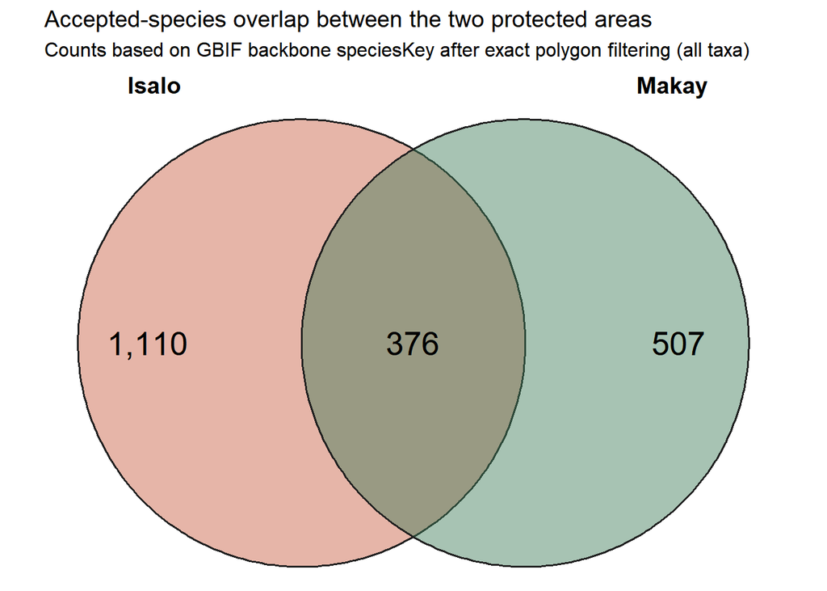

```r
venn_polygons <- bind_rows(
  tibble(
    x = -0.8 + 1.6 * cos(seq(0, 2 * pi, length.out = 360)),
    y = 1.6 * sin(seq(0, 2 * pi, length.out = 360)),
    set = "Isalo"
  ),
  tibble(
    x = 0.8 + 1.6 * cos(seq(0, 2 * pi, length.out = 360)),
    y = 1.6 * sin(seq(0, 2 * pi, length.out = 360)),
    set = "Makay"
  )
)

ggplot() +
  geom_polygon(
    data = venn_polygons,
    aes(x = x, y = y, group = set, fill = set),
    color = "#1f1f1f",
    alpha = 0.45,
    linewidth = 0.7
  ) +
  annotate("text", x = -1.9, y = 0, label = comma(sum(unique_species$area == "Isalo")), size = 7) +
  annotate("text", x = 0, y = 0, label = comma(shared_species_count), size = 7) +
  annotate("text", x = 1.9, y = 0, label = comma(sum(unique_species$area == "Makay")), size = 7) +
  annotate("text", x = -1.85, y = 1.85, label = "Isalo", fontface = "bold", size = 5) +
  annotate("text", x = 1.85, y = 1.85, label = "Makay", fontface = "bold", size = 5) +
  scale_fill_manual(values = c(Isalo = area_colors[["Isalo"]], Makay = area_colors[["Makay"]])) +
  coord_equal() +
  labs(
    title = "Accepted-species overlap between the two protected areas",
    subtitle = "Counts based on GBIF backbone speciesKey after exact polygon filtering (all taxa)"
  ) +
  theme_void(base_size = 12) +
  theme(legend.position = "none")
```

Jaccard similarity (all taxa): 18.9%.

## Class representation

The figure shows the twelve classes contributing the most accepted species across the two areas combined.

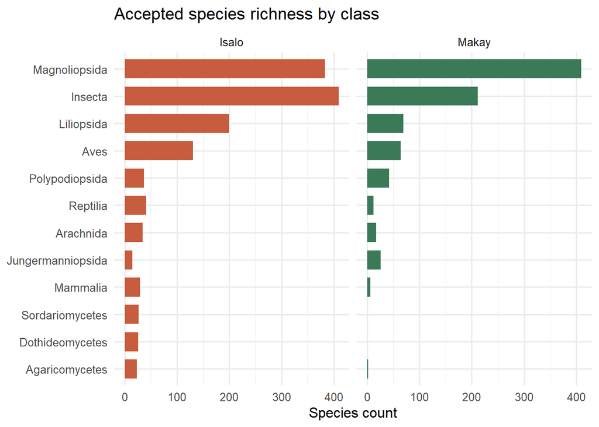

```r
class_comparison <- area_occurrences |>
  filter(!is.na(speciesKey), !is.na(class)) |>
  distinct(area, class, speciesKey) |>
  count(area, class, name = "species_count")

top_classes <- class_comparison |>
  summarise(total_species = sum(species_count), .by = class) |>
  slice_max(total_species, n = 12, with_ties = FALSE) |>
  arrange(total_species) |>
  pull(class)

class_plot_data <- class_comparison |>
  filter(class %in% top_classes) |>
  complete(area, class = top_classes, fill = list(species_count = 0)) |>
  mutate(class = factor(class, levels = top_classes))

ggplot(class_plot_data, aes(x = species_count, y = class, fill = area)) +
  geom_col(show.legend = FALSE, width = 0.7) +
  facet_wrap(~ area) +
  scale_fill_manual(values = area_colors) +
  scale_x_continuous(labels = comma) +
  labs(
    title = "Accepted species richness by class",
    x = "Species count",
    y = NULL
  ) +
  theme_minimal(base_size = 12)
```

## Sensitivity analysis

The robustness of the main contrast was tested by recomputing counts under alternative record filters: excluding the largest dataset(s) of each area, restricting to preserved specimens, and filtering on coordinate uncertainty (available for only ~7% of records in both areas).

```r
top_dataset_by_area <- dataset_stats |> group_by(area) |> slice_head(n = 1) |> ungroup()
top3_by_area <- dataset_stats |> group_by(area) |> slice_head(n = 3) |> ungroup()

sensitivity_filters <- list(
  list(id = "S1", label = "Baseline (no exclusion)", f = function(d) d),
  list(id = "S2", label = "Excluding largest dataset per area", f = function(d)
    d |> anti_join(top_dataset_by_area |> select(area, datasetKey), by = c("area", "datasetKey"))),
  list(id = "S3", label = "Excluding three largest datasets per area", f = function(d)
    d |> anti_join(top3_by_area |> select(area, datasetKey), by = c("area", "datasetKey"))),
  list(id = "S4", label = "Preserved specimens only", f = function(d)
    d |> filter(basisOfRecord == "PRESERVED_SPECIMEN")),
  list(id = "S5", label = "Excluding uncertainty > 1,000 m (unknowns kept)", f = function(d)
    d |> filter(is.na(coordinateUncertaintyInMeters) | coordinateUncertaintyInMeters <= 1000)),
  list(id = "S6", label = "Known uncertainty <= 10,000 m only (unknowns excluded)", f = function(d)
    d |> filter(!is.na(coordinateUncertaintyInMeters), coordinateUncertaintyInMeters <= 10000)),
  list(id = "S7", label = "Excluding iNaturalist", f = function(d)
    d |> filter(datasetKey != "50c9509d-22c7-4a22-a47d-8c48425ef4a7"))
)

sensitivity_results <- map_dfr(sensitivity_filters, \(fltr) {
  fltr$f(area_occurrences) |>
    summarise(
      occurrences = n(),
      species_all = n_distinct(speciesKey[!is.na(speciesKey)]),
      species_vascular = n_distinct(speciesKey[!is.na(speciesKey) & kingdom == "Plantae" & phylum == "Tracheophyta"]),
      .by = area
    ) |>
    mutate(filter_id = fltr$id, filter_label = fltr$label)
}) |>
  left_join(protected_areas |> st_drop_geometry() |> select(area, AREA_KM2), by = "area") |>
  mutate(
    occ_density = occurrences / AREA_KM2 * 100,
    species_density = species_all / AREA_KM2 * 100
  )

sensitivity_wide <- sensitivity_results |>
  select(-AREA_KM2) |>
  pivot_wider(names_from = area, values_from = c(occurrences, occ_density, species_all, species_density, species_vascular)) |>
  mutate(
    occ_density_ratio = occ_density_Isalo / occ_density_Makay,
    species_density_ratio = species_density_Isalo / species_density_Makay,
    raw_species_ratio = species_all_Isalo / species_all_Makay,
    vascular_species_ratio = species_vascular_Isalo / species_vascular_Makay
  )
```

```r
sensitivity_wide |>
  transmute(
    filter_id,
    filter_label,
    `Isalo occ.` = comma(occurrences_Isalo),
    `Makay occ.` = comma(occurrences_Makay),
    `Isalo sp.` = comma(species_all_Isalo),
    `Makay sp.` = comma(species_all_Makay),
    `Vasc. sp. Isalo` = comma(species_vascular_Isalo),
    `Vasc. sp. Makay` = comma(species_vascular_Makay),
    `Occ. density ratio` = round(occ_density_ratio, 1),
    `Sp. density ratio` = round(species_density_ratio, 1)
  ) |>
  knitr::kable(caption = "Sensitivity of the Makay/Isalo contrast to alternative record filters")
```

Sensitivity of the Makay/Isalo contrast to alternative record filters

| filter_id | filter_label | Isalo occ. | Makay occ. | Isalo sp. | Makay sp. | Vasc. sp. Isalo | Vasc. sp. Makay | Occ. density ratio | Sp. density ratio |
| --- | --- | --- | --- | --- | --- | --- | --- | --- | --- |
| S1 | Baseline (no exclusion) | 53,115 | 7,341 | 1,486 | 883 | 622 | 524 | 33.9 | 7.9 |
| S2 | Excluding largest dataset per area | 37,474 | 4,986 | 1,445 | 808 | 622 | 452 | 35.2 | 8.4 |
| S3 | Excluding three largest datasets per area | 20,791 | 2,062 | 1,334 | 459 | 622 | 165 | 47.2 | 13.6 |
| S4 | Preserved specimens only | 4,955 | 5,995 | 668 | 727 | 450 | 514 | 3.9 | 4.3 |
| S5 | Excluding uncertainty > 1,000 m (unknowns kept) | 51,560 | 7,179 | 1,421 | 856 | 586 | 518 | 33.6 | 7.8 |
| S6 | Known uncertainty <= 10,000 m only (unknowns excluded) | 3,004 | 373 | 525 | 153 | 257 | 23 | 37.7 | 16.1 |
| S7 | Excluding iNaturalist | 49,223 | 6,863 | 1,183 | 787 | 465 | 515 | 33.6 | 7.0 |

## Audit notes

Differences from the earlier version of this report: